# Salmon farming model

Using Ordinary Differential Equation (ODE) with STAN to model the salmon farming dynamics

Author

Nicoló Foppa Pedretti

Published

November 22, 2025

## 1 Introduction

This model describes the dynamics of a salmon population in an aquaculture setting, accounting for growth, mortality, and harvesting based on a Gaussian weight distribution. Harvesting targets salmon with weights $w \geq 5\text{kg}$. The model tracks the remaining population (number ($N$), mean weight ($W$), variance ($V$)) and the cumulative harvested population (number ($N_{\text{h}}$), mean weight ($W_{\text{h}}$), variance ($V_{\text{h}}$)), along with some parameters (mortality rate ($\mu$), growth rate ($g_r$)). The total biomass is computed as $B = N \cdot W$.

Variables:

- Remaining Population:
  - $N(t)$: Number of salmon (dimensionless)
  - $W(t)$: Mean weight of remaining salmon (kg)
  - $V(t)$: Variance of remaining salmon weights (kg<sup>2</sup>)
- Harvested Population:
  - $N_{\text{h}}$: Cumulative number of h salmon (dimensionless)
  - $W_{\text{h}}$: Cumulative mean weight of h salmon (kg)
  - $V_{\text{h}}$: Cumulative variance of h salmon weights ((kg<sup>2</sup>)

The derived output is the total biomass of remaining salmon (kg), $B(t) = N(t) \cdot W(t)$. See [1], [2], [3]

## 2 Assumptions

- The initial salmon weight will follow a normal distribution with a specified mean ($\mu_0$) and standard deviation ($\sigma_0$), and harvesting will target salmon above 5kg based on this distribution. Since modeling a full size distribution typically requires **partial differential equations (PDEs)** for continuous weight classes, we’ll approximate the size structure with a simplified ODE system by tracking the moments of the distribution.
- Assume the weight distribution remains approximately Gaussian over time, $W(t) \sim \mathcal{N}(W(t), V(t))$, where $W(t)$ is the mean and $\sqrt{V(t)}$ is the standard deviation.
- Harvesting removes salmon with $w \geq 5$, calculated using the cumulative distribution function (CDF) of the normal distribution:
  $$\text{Fraction harvested} = P(w \geq 5) = 1 - \Phi\left(\frac{5 - W(t)}{\sqrt{V(t)}}\right) \qquad \text{where } \Phi \text{ is the standard normal CDF.}$$
- Harvesting affects $N$, $W$, and $V$, as larger salmon are removed, shifting the mean and variance.
- We express the post-harvest mean weight ($W_{\text{post}}$) and variance ($V_{\text{post}}$) as the conditional mean and variance of a Gaussian distribution truncated below 5kg because harvesting removes salmon with weights $w \geq 5\text{kg}$, leaving only those with $w<5\text{kg}$. We need to compute the mean and variance of this truncated Gaussian distribution for the remaining population (see Section 7 for additional context)
- In order to include the mean and variance of the harvested salmon weights as state variables in the salmon harvesting model, we need to track the mean weight ($W_{\text{harvested}}$) and variance ($V_{\text{harvested}}$) of the salmon with weights $w \geq 5\text{kg}$ over time. These new state variables will represent the cumulative mean and variance of the harvested salmon, updated as harvesting occurs. Since harvesting is a continuous process in the ODE system, we’ll model the dynamics of $W_{\text{harvested}}$ and $V_{\text{harvested}}$ by accumulating the contributions of harvested salmon, weighted by the harvesting rate. New State Variables: $W_{\text{harvested}}(t)$ (mean weight in kg of all salmon harvested up to time t), $V_{\text{harvested}}$ (variance of weights in kg<sup>2</sup> of all salmon harvested up to time t). However we face some challenges because harvesting is modeled as a continuous rate, so $W_{\text{harvested}}$ and $V_{\text{harvested}}$ represent the average properties of the cumulative harvested population. The instantaneous mean and variance of harvested salmon at time $t$ are given by the truncated Gaussian $w \geq 5$, but we need to track their cumulative effect. As a solution we introduce `ODEs` for the two parameters that update based on the instantaneous harvested mean and variance, we use an auxiliary state variable
  $$\frac{dN_{\text{harvested}}}{dt} = h \left[ 1 - \Phi\left(\frac{5 - W}{\sqrt{V}}\right) \right] N$$
  to track the cumulative number of harvested salmon, which helps normalize the mean and variance calculations.
- The instantaneous mean and variance of harvested salmon at time t, given $\alpha = \frac{5 - W(t)}{\sqrt{V(t)}}$, are:
  $$W_{\text{inst}}(t) = W(t) + \sqrt{V(t)} \cdot \frac{\phi(\alpha)}{1 - \Phi(\alpha)} \qquad \qquad V_{\text{inst}}(t) = V(t) \left[ 1 + \frac{\phi(\alpha) \cdot \alpha}{1 - \Phi(\alpha)} - \left( \frac{\phi(\alpha)}{1 - \Phi(\alpha)} \right)^2 \right]$$
  which lead to

  $$\begin{array}{l}
  \frac{dW_{\text{harvested}}}{dt} = \frac{h \left[ 1 - \Phi\left(\frac{5 - W}{\sqrt{V}}\right) \right] N (W_{\text{inst}} - W_{\text{harvested}})}{N_{\text{harvested}} + \epsilon} \\
  \frac{dV_{\text{harvested}}}{dt} = \frac{h \left[ 1 - \Phi\left(\frac{5 - W}{\sqrt{V}}\right) \right] N [V_{\text{inst}} + (W_{\text{inst}} - W_{\text{harvested}})^2 - V_{\text{harvested}}]}{N_{\text{harvested}} + \epsilon}
  \end{array}$$

## 3 Equation

$$\begin{array}{l}
\frac{dN}{dt} = -(\mu + h_r)N \\
\frac{dW}{dt} = g_r\left(1 - \frac{W}{W_{max}} \right) - h_r(W-W_{post}) \\
\frac{dV}{dt} = \sigma^2_gg_r - h_r(V-V_{post}) \\
\frac{dN_{\text{h}}}{dt} = h_r N \\
\frac{dW_{\text{h}}}{dt} = \frac{h_r N (W_{\text{inst}} - W_{\text{h}})}{N_{\text{h}} + \epsilon} \\
\frac{dV_{\text{h}}}{dt} = \frac{h_r N [V_{\text{inst}} + (W_{\text{inst}} - W_{\text{h}})^2 - V_{\text{h}}]}{N_{\text{h}} + \epsilon},
\end{array}$$

## 4 `R` and `stan` code

Ordinary differential equations (ODEs) model dynamic systems in physics, biology, and engineering, but analytical solutions are often infeasible for complex cases. For numerical approximation, we pair R with Stan, which provides efficient ODE solvers (bdf integrators) via interfaces such cmdstanr. This setup enables straightforward approximation of ODE trajectories in an open-source environment, without relying on Bayesian inference features.

```r
library(kableExtra)
library(cmdstanr)
library(dplyr)
library(ggplot2)
library(gridExtra)
library(posterior)

stan_file = "../salmon/farm_model.stan"
mod <- cmdstan_model(stan_file)
```

In the context of ordinary differential equations (ODEs), initial conditions refer to the specified values of the dependent variables at the starting point of the independent variable, typically time t=0. These conditions are crucial for solving initial value problems, as they provide the necessary constraints to determine a unique solution trajectory from the differential equations, preventing ambiguity in the system’s evolution

```r
# Initial state
y0 <- c(50000,  # Number of fish
        2.5,    # Mean weight of the initial population
        0.5,    # Var weight of the initial population
        0,      # Number of harvested fish
        0,      # Mean weight of the harvested population
        0.01)   # Var weight of the harvsted population

# Time points for simulation (weeks)
ts <- seq(from = 1, to = 52, by = 1)

# Prepare data for Stan
stan_data <- list(
  T = length(ts),   # Number of weeks ahead
  ts = ts,          # Vector of times
  y0 = y0,          # initial conditions
  h = 0.8,          # % of harvested fish over treshold
  gr = 0.05,        # growth ratio (%)
  tw = 5,           # target weight (kg)
  mu = 0.001,       # death rate (%)
  W_max = 12,       # max weight allowed per fish (for growth equation)
  sigma_g = 0.3     # sd of growth rate
)
```

Run the simulation:

```r
fit <- mod$sample(
  data = stan_data,
  chains = 1,
  iter_sampling = 1,
  iter_warmup = 0,
  fixed_param = TRUE,
  refresh = 0
)
```

```
Running MCMC with 1 chain...

Chain 1 finished in 0.1 seconds.
```

Extract results:

```r
# Extract results
draws_df <- fit$draws(format = "draws_df")

# Process the results
farm_data <- data.frame(
  time = ts,
  num_salmon = numeric(length(ts)),
  mean_weight = numeric(length(ts)),
  var_weight = numeric(length(ts)),
  har_salmon = numeric(length(ts)),
  mean_weight_har_salmon = numeric(length(ts)),
  var_weight_har_salmon = numeric(length(ts))
)

for (t in 1:length(ts)) {
  farm_data$num_salmon[t] <- ceiling(draws_df[[paste0("y_hat[", t, ",1]")]])
  farm_data$mean_weight[t] <- draws_df[[paste0("y_hat[", t, ",2]")]]
  farm_data$var_weight[t] <- draws_df[[paste0("y_hat[", t, ",3]")]]
  farm_data$har_salmon[t] <- floor(draws_df[[paste0("y_hat[", t, ",4]")]])
  farm_data$mean_weight_har_salmon[t] <- draws_df[[paste0("y_hat[", t, ",5]")]]
  farm_data$var_weight_har_salmon[t] <- draws_df[[paste0("y_hat[", t, ",6]")]]
}

farm_data = rbind(c(0,y0),farm_data)
farm_data |>
  head(n = 10) |>
  kbl(format = "markdown") |>
  kable_classic_2(full_width = F)
```

| time | num_salmon | mean_weight | var_weight | har_salmon | mean_weight_har_salmon | var_weight_har_salmon |
| --- | --- | --- | --- | --- | --- | --- |
| 0 | 50000 | 2.50000 | 0.500000 | 0 | 0.00000 | 0.0100000 |
| 1 | 49942 | 2.53950 | 0.504500 | 8 | 5.17831 | 0.0286423 |
| 2 | 49880 | 2.57884 | 0.508999 | 20 | 5.18045 | 0.0292905 |
| 3 | 49815 | 2.61801 | 0.513498 | 35 | 5.18276 | 0.0300002 |
| 4 | 49746 | 2.65702 | 0.517997 | 55 | 5.18524 | 0.0307700 |
| 5 | 49671 | 2.69587 | 0.522495 | 80 | 5.18787 | 0.0315983 |
| 6 | 49590 | 2.73455 | 0.526992 | 111 | 5.19064 | 0.0324836 |
| 7 | 49501 | 2.77308 | 0.531488 | 151 | 5.19354 | 0.0334244 |
| 8 | 49402 | 2.81144 | 0.535981 | 200 | 5.19658 | 0.0344191 |
| 9 | 49292 | 2.84964 | 0.540471 | 261 | 5.19973 | 0.0354660 |

## 5 Results

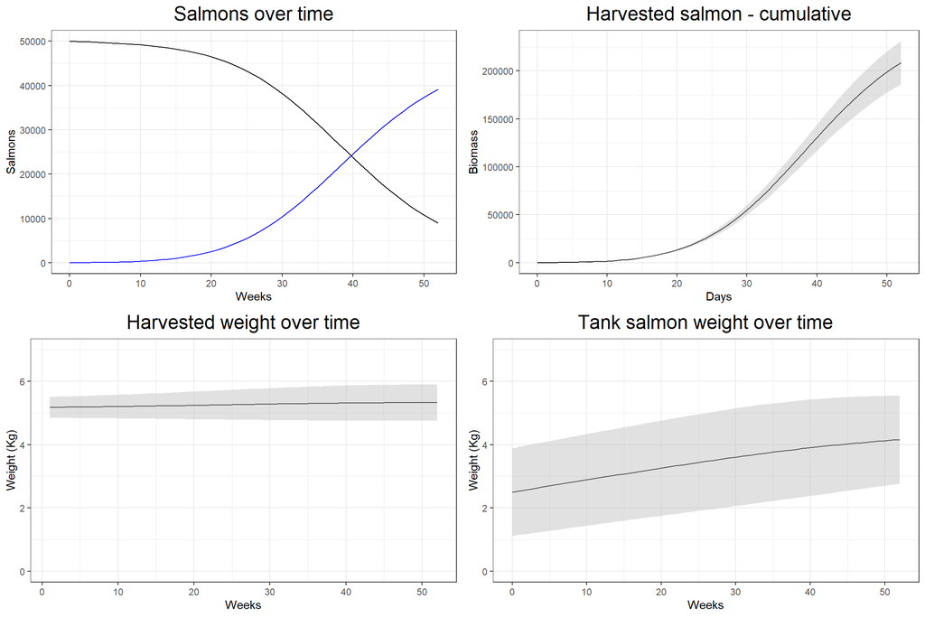

## 6 References

[1]

E. Legrand *et al.*, “Salmon farming alters the structure and functioning of norwegian maerl bed communities,” *Aquatic Conservation: Marine and Freshwater Ecosystems*, vol. 34, no. 4, p. e4142, 2024, doi: https://doi.org/10.1002/aqc.4142.

[2]

A. C. Harvey *et al.*, “Does density influence relative growth performance of farm, wild and f<sub>1</sub> hybrid atlantic salmon in semi-natural and hatchery common garden conditions?” *Royal Society Open Science*, vol. 3, no. 7, p. 160152, 2016, doi: 10.1098/rsos.160152.

[3]

R. B. M. Pincinato, F. Asche, H. Bleie, A. Skrudland, and M. Stormoen, “Factors influencing production loss in salmonid farming,” *Aquaculture*, vol. 532, p. 736034, 2021, doi: https://doi.org/10.1016/j.aquaculture.2020.736034.

## 7 Appendix

### 7.1 Truncated Gaussian Distribution

For a Gaussian random variable $w \sim \mathcal{N}(\mu, \sigma^2)$, truncated to $w < a$, the probability density function of the truncated distribution is:

$$f(w|w < a) = \frac{\frac{1}{\sqrt{2 \pi \sigma^2}} \exp \left( - \frac{(w-\mu)^2}{2\sigma^2} \right) }{\Phi \left( \frac{a-\mu}{\sigma} \right)} \quad \text{for } w < a$$

where $\Phi(z)$ is the standard normal CDF, and the denominator $\Phi\left(\frac{a - \mu}{\sigma}\right) = P(w < a)$ is the probability of $w < a$. In our case:

- $\Phi(z) = \frac{1}{\sqrt{2\pi}} \int^{z}_{-\infty} e^{\frac{-u^2}{2}}du$
- $\mu = W(t)$: Mean weight before harvesting
- $\sigma^2 = V(t)$: Variance before harvesting
- $a=5$: Truncation point (harvest salmon with $w \geq 5$)

Let’s define:

- $\alpha = \frac{a - \mu}{\sigma} = \frac{5 - W(t)}{\sqrt{V(t)}}$: Standardized truncation point
- $\phi(z) = \frac{1}{\sqrt{2\pi}} \exp\left(-\frac{z^2}{2}\right)$: Standard normal PDF
- $\Phi(\alpha) = P(z < \alpha)$: CDF at $\alpha$

The fraction of salmon remaining after harvesting is $\Phi(\alpha)$, and the fraction harvested is $1 - \Phi(\alpha)$.

#### 7.1.1 Conditional Mean ($W_{\text{post}}$)

The mean of a Gaussian distribution truncated at $w < a$, substituting $\mu = W(t)$, $\sigma = \sqrt{V(t)}$, $a = 5$ and $\alpha = \frac{5 - W(t)}{\sqrt{V(t)}}$ is:

$$\mathbb{E}[w|w<a] = \mu - \sigma \frac{\phi \left( \frac{a-\mu}{\sigma}\right)}{\Phi \left( \frac{a-\mu}{\sigma}\right)} \quad \longrightarrow \quad W_{\text{post}} = W(t) - \sqrt{V(t)} \frac{\phi \left( \frac{5-W(t)}{\sqrt{V(t)}}\right)}{\Phi \left( \frac{5-W(t)}{\sqrt{V(t)}}\right)} \quad \longrightarrow \quad W_{\text{post}} = W(t) - \sqrt{V(t)} \frac{\phi(\alpha)}{\Phi(\alpha)}$$

The term $\frac{\phi(\alpha)}{\Phi(\alpha)}$ is the hazard function (or inverse **Mills ratio**) for the standard normal, which adjusts the mean downward since larger weights are removed.

#### 7.1.2 Conditional Variance ($V_{\text{post}}$)

The variance of the truncated Gaussian $w < a$, substituting $\sigma^2 = V(t)$, $\mu = W(t)$, $a=5$, and $\alpha = \frac{5 - W(t)}{\sqrt{V(t)}}$ is:

$$Var[w|w<a] = \sigma^2 \left[ 1 - \frac{\phi \left( \frac{a-\mu}{\sigma}\right) \frac{a-\mu}{\sigma}}{\Phi \left( \frac{a-\mu}{\sigma}\right)} - \left( \frac{\phi \left( \frac{a-\mu}{\sigma}\right)}{\Phi \left( \frac{a-\mu}{\sigma}\right)} \right)^2 \right] \qquad \longrightarrow \qquad V_{\text{post}} = V(t) \left[ 1 - \frac{\phi(\alpha) \alpha}{\Phi(\alpha)} - \left( \frac{\phi(\alpha)}{\Phi(\alpha)} \right)^2 \right]$$
This expression accounts for the reduced variance after removing the upper tail of the distribution. Behavior:

- If $W \ll 5$, $\alpha$ is large, $\Phi(\alpha) \approx 1$, $\phi(\alpha) \approx 0$, $W_{\text{post}} \approx W$,$V_{\text{post}} \approx V$, as few salmon are harvested.
- If $W \gg 5$, $\alpha$ is negative and large, $\Phi(\alpha) \approx 0$, harvesting dominates, but $W_{\text{post}}$ and $V_{\text{post}}$ stabilize to values reflecting the truncated distribution.

Numerical Stability: Ensure $V > 0$ to avoid division by zero in $\alpha$. In practice, $V_{\text{post}}$ is always positive but smaller than (V).